# F0

Jesse Leigh Patsolic

# [Full plots here](http://cis.jhu.edu/~jesse/fotd/2017/05/15/)

## F0 as number on side

Here the F0 featrue is calculated from the z-scored data and printed as a number on teh right hand side of the plot.

```
## quartz_off_screen quartz_off_screen quartz_off_screen quartz_off_screen
##                 4                 4                 4                 4
```

## F0 as number on side

```
##          CR12ndA    GluR22ndA    PV1stA    VAChT4thA    GABARa14thA
## ch_names "CR1_2ndA" "GluR2_2ndA" "PV_1stA" "VAChT_4thA" "GABARa1_4thA"
## abb      "CR1"      "GR2"        "PV1"     "VAC"        "GABAR"
##          VGluT22ndA    tubulin8thA    VGluT31stA    TH5thA
## ch_names "VGluT2_2ndA" "tubulin_8thA" "VGluT3_1stA" "TH_5thA"
## abb      "VGT2"        "t8A"          "VGT3"        "TH5"
##          VGluT13rdA    NR2B9thA    VGluT18thA    synapsinR7thA
## ch_names "VGluT1_3rdA" "NR2B_9thA" "VGluT1_8thA" "synapsinR_7thA"
## abb      "VGT13"       "NR2"       "VGT18"       "sR7"
##          GAD6thA    VGAT5thA    Synpod3rdA    synapsinGP5thA    psd8thA
## ch_names "GAD_6thA" "VGAT_5thA" "Synpod_3rdA" "synapsinGP_5thA" "psd_8thA"
## abb      "GAD"      "VGA"       "S3A"         "sGP"             "p8A"
##          dapi1stA    GABABR13rdA    NMDAR16thA    NOS9thA
## ch_names "dapi_1stA" "GABABR1_3rdA" "NMDAR1_6thA" "NOS_9thA"
## abb      "d1A"       "GABAB"        "NMD"         "NOS"
##          gephyrin1stA
## ch_names "gephyrin_1stA"
## abb      "g1A"
```

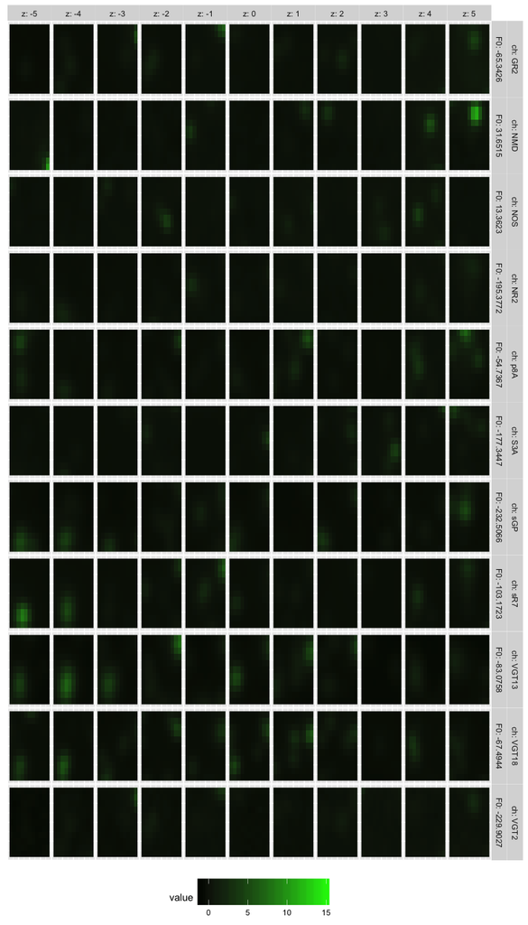

## F0 as a matrix :X:

Here I compute F0 as above and join a matrix to the z = 6 slot that is full of the same F0 value. The F0 value is much larger than the pixel values and overshadows the colorbar.

```
## quartz_off_screen quartz_off_screen quartz_off_screen quartz_off_screen
##                 4                 4                 4                 4
```

## F0 as matrix

```
##          CR12ndA    GluR22ndA    PV1stA    VAChT4thA    GABARa14thA
## ch_names "CR1_2ndA" "GluR2_2ndA" "PV_1stA" "VAChT_4thA" "GABARa1_4thA"
## abb      "CR1"      "GR2"        "PV1"     "VAC"        "GABAR"
##          VGluT22ndA    tubulin8thA    VGluT31stA    TH5thA
## ch_names "VGluT2_2ndA" "tubulin_8thA" "VGluT3_1stA" "TH_5thA"
## abb      "VGT2"        "t8A"          "VGT3"        "TH5"
##          VGluT13rdA    NR2B9thA    VGluT18thA    synapsinR7thA
## ch_names "VGluT1_3rdA" "NR2B_9thA" "VGluT1_8thA" "synapsinR_7thA"
## abb      "VGT13"       "NR2"       "VGT18"       "sR7"
##          GAD6thA    VGAT5thA    Synpod3rdA    synapsinGP5thA    psd8thA
## ch_names "GAD_6thA" "VGAT_5thA" "Synpod_3rdA" "synapsinGP_5thA" "psd_8thA"
## abb      "GAD"      "VGA"       "S3A"         "sGP"             "p8A"
##          dapi1stA    GABABR13rdA    NMDAR16thA    NOS9thA
## ch_names "dapi_1stA" "GABABR1_3rdA" "NMDAR1_6thA" "NOS_9thA"
## abb      "d1A"       "GABAB"        "NMD"         "NOS"
##          gephyrin1stA
## ch_names "gephyrin_1stA"
## abb      "g1A"
```

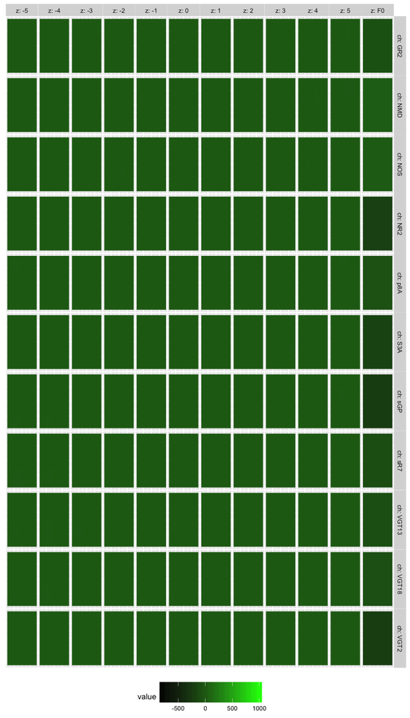

## F0 averaged :X:

Here I compute F0 as above and average it by the number of pixels = 1331 in each cube and add it as a matrix same as above.

Because most of the pixels values are small, this doesn’t seem to be visually helpful either.

```
## quartz_off_screen quartz_off_screen quartz_off_screen quartz_off_screen
##                 4                 4                 4                 4
```

## F0 matrix divided by 1331 = 11^3

```
##          CR12ndA    GluR22ndA    PV1stA    VAChT4thA    GABARa14thA
## ch_names "CR1_2ndA" "GluR2_2ndA" "PV_1stA" "VAChT_4thA" "GABARa1_4thA"
## abb      "CR1"      "GR2"        "PV1"     "VAC"        "GABAR"
##          VGluT22ndA    tubulin8thA    VGluT31stA    TH5thA
## ch_names "VGluT2_2ndA" "tubulin_8thA" "VGluT3_1stA" "TH_5thA"
## abb      "VGT2"        "t8A"          "VGT3"        "TH5"
##          VGluT13rdA    NR2B9thA    VGluT18thA    synapsinR7thA
## ch_names "VGluT1_3rdA" "NR2B_9thA" "VGluT1_8thA" "synapsinR_7thA"
## abb      "VGT13"       "NR2"       "VGT18"       "sR7"
##          GAD6thA    VGAT5thA    Synpod3rdA    synapsinGP5thA    psd8thA
## ch_names "GAD_6thA" "VGAT_5thA" "Synpod_3rdA" "synapsinGP_5thA" "psd_8thA"
## abb      "GAD"      "VGA"       "S3A"         "sGP"             "p8A"
##          dapi1stA    GABABR13rdA    NMDAR16thA    NOS9thA
## ch_names "dapi_1stA" "GABABR1_3rdA" "NMDAR1_6thA" "NOS_9thA"
## abb      "d1A"       "GABAB"        "NMD"         "NOS"
##          gephyrin1stA
## ch_names "gephyrin_1stA"
## abb      "g1A"
```

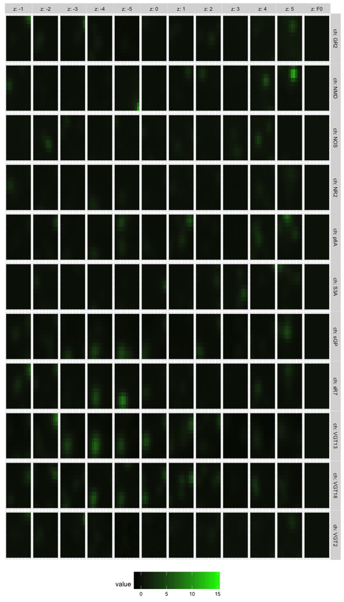

## Here I calculate F0 from the raw data and log_10 it :X:

Here I am plotting the Z-scored data in the synaptograms and the log_10 of the F0 value I get from the raw data. Also, no good.

```
## quartz_off_screen quartz_off_screen quartz_off_screen quartz_off_screen
##                 4                 4                 4                 4
```

## F0 of raw data log_10 transformed

```
##          CR12ndA    GluR22ndA    PV1stA    VAChT4thA    GABARa14thA
## ch_names "CR1_2ndA" "GluR2_2ndA" "PV_1stA" "VAChT_4thA" "GABARa1_4thA"
## abb      "CR1"      "GR2"        "PV1"     "VAC"        "GABAR"
##          VGluT22ndA    tubulin8thA    VGluT31stA    TH5thA
## ch_names "VGluT2_2ndA" "tubulin_8thA" "VGluT3_1stA" "TH_5thA"
## abb      "VGT2"        "t8A"          "VGT3"        "TH5"
##          VGluT13rdA    NR2B9thA    VGluT18thA    synapsinR7thA
## ch_names "VGluT1_3rdA" "NR2B_9thA" "VGluT1_8thA" "synapsinR_7thA"
## abb      "VGT13"       "NR2"       "VGT18"       "sR7"
##          GAD6thA    VGAT5thA    Synpod3rdA    synapsinGP5thA    psd8thA
## ch_names "GAD_6thA" "VGAT_5thA" "Synpod_3rdA" "synapsinGP_5thA" "psd_8thA"
## abb      "GAD"      "VGA"       "S3A"         "sGP"             "p8A"
##          dapi1stA    GABABR13rdA    NMDAR16thA    NOS9thA
## ch_names "dapi_1stA" "GABABR1_3rdA" "NMDAR1_6thA" "NOS_9thA"
## abb      "d1A"       "GABAB"        "NMD"         "NOS"
##          gephyrin1stA
## ch_names "gephyrin_1stA"
## abb      "g1A"
```

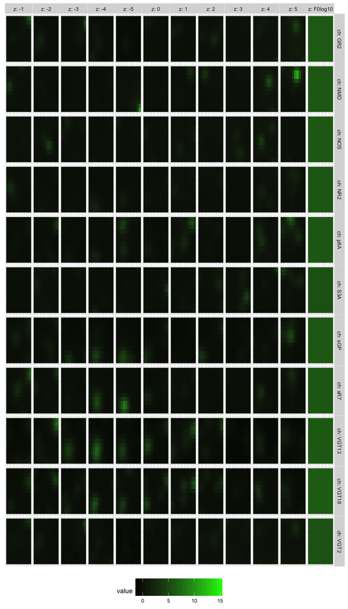

## Everything squashed to 0-1 :MAYBE?:

Here I am plotting the data squished to 0-1, then I calculate the F0 value on the squished data and then plot F0 squished to 0-1.

```
## quartz_off_screen quartz_off_screen quartz_off_screen quartz_off_screen
##                 4                 4                 4                 4
```

## F0 on 0-1 scaled data, scaled to 0-1

```
##          CR12ndA    GluR22ndA    PV1stA    VAChT4thA    GABARa14thA
## ch_names "CR1_2ndA" "GluR2_2ndA" "PV_1stA" "VAChT_4thA" "GABARa1_4thA"
## abb      "CR1"      "GR2"        "PV1"     "VAC"        "GABAR"
##          VGluT22ndA    tubulin8thA    VGluT31stA    TH5thA
## ch_names "VGluT2_2ndA" "tubulin_8thA" "VGluT3_1stA" "TH_5thA"
## abb      "VGT2"        "t8A"          "VGT3"        "TH5"
##          VGluT13rdA    NR2B9thA    VGluT18thA    synapsinR7thA
## ch_names "VGluT1_3rdA" "NR2B_9thA" "VGluT1_8thA" "synapsinR_7thA"
## abb      "VGT13"       "NR2"       "VGT18"       "sR7"
##          GAD6thA    VGAT5thA    Synpod3rdA    synapsinGP5thA    psd8thA
## ch_names "GAD_6thA" "VGAT_5thA" "Synpod_3rdA" "synapsinGP_5thA" "psd_8thA"
## abb      "GAD"      "VGA"       "S3A"         "sGP"             "p8A"
##          dapi1stA    GABABR13rdA    NMDAR16thA    NOS9thA
## ch_names "dapi_1stA" "GABABR1_3rdA" "NMDAR1_6thA" "NOS_9thA"
## abb      "d1A"       "GABAB"        "NMD"         "NOS"
##          gephyrin1stA
## ch_names "gephyrin_1stA"
## abb      "g1A"
```

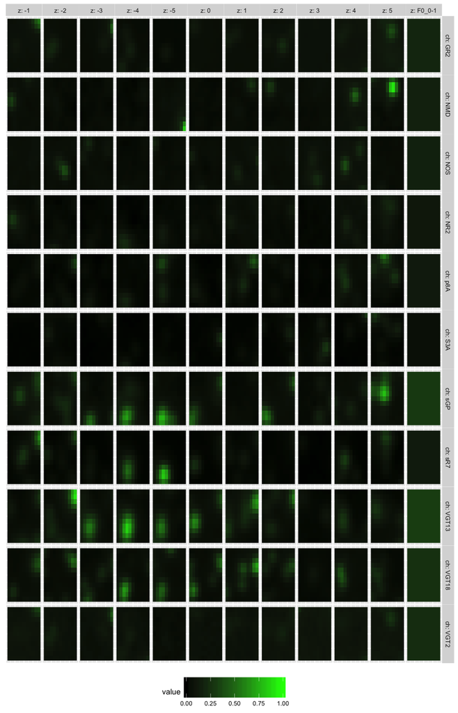

## F0 as separate column on side :better?:

Here I’m back to the Z-scored data for synaptograms and it’s corresponding F0, where the F0 value is plotted separately adn on it’s own color bar. Seems a bit messy, but better than the above attempts.

```
## quartz_off_screen quartz_off_screen quartz_off_screen quartz_off_screen
##                 4                 4                 4                 4
```

```
##          CR12ndA    GluR22ndA    PV1stA    VAChT4thA    GABARa14thA
## ch_names "CR1_2ndA" "GluR2_2ndA" "PV_1stA" "VAChT_4thA" "GABARa1_4thA"
## abb      "CR1"      "GR2"        "PV1"     "VAC"        "GABAR"
##          VGluT22ndA    tubulin8thA    VGluT31stA    TH5thA
## ch_names "VGluT2_2ndA" "tubulin_8thA" "VGluT3_1stA" "TH_5thA"
## abb      "VGT2"        "t8A"          "VGT3"        "TH5"
##          VGluT13rdA    NR2B9thA    VGluT18thA    synapsinR7thA
## ch_names "VGluT1_3rdA" "NR2B_9thA" "VGluT1_8thA" "synapsinR_7thA"
## abb      "VGT13"       "NR2"       "VGT18"       "sR7"
##          GAD6thA    VGAT5thA    Synpod3rdA    synapsinGP5thA    psd8thA
## ch_names "GAD_6thA" "VGAT_5thA" "Synpod_3rdA" "synapsinGP_5thA" "psd_8thA"
## abb      "GAD"      "VGA"       "S3A"         "sGP"             "p8A"
##          dapi1stA    GABABR13rdA    NMDAR16thA    NOS9thA
## ch_names "dapi_1stA" "GABABR1_3rdA" "NMDAR1_6thA" "NOS_9thA"
## abb      "d1A"       "GABAB"        "NMD"         "NOS"
##          gephyrin1stA
## ch_names "gephyrin_1stA"
## abb      "g1A"
```

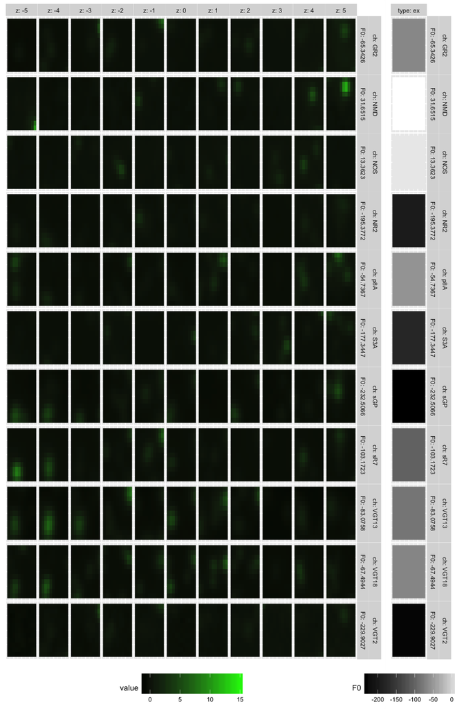